# A5 Claims Development by Layer

R. Sahasrabuddhe

April 17, 2016

## Cliff’s Summary

Know the process for setting up base triangle and then convert the base LDFs to any layer

Main formulas to memorize:

- $LEV(X; \Phi \sim Exp(\theta)) = \theta \: \left[ 1 - \operatorname{exp}\left\{-\left(\dfrac{x}{\theta}\right)\right\} \right]$
- $\begin{align} F_{ij}^X = F_{nj}^B \times \frac{LEV(X;\Phi_{i\infty})\div LEV(B;\Phi_{n\infty})}{LEV(X;\Phi_{ij}) \div LEV(B;\Phi_{nj})} \end{align}$

Know the assumptions used

### Types of Exam Questions

Haven’t done TIA practice questions

**Setup Base Triangle**

- 2013 #5: set up base triangle with trend and all
  - Can start trend from bottom left cell

## Introduction

**2 Key Ideas**:

1. Convert a triangle to one level of trend and layer of losses
   - This is then used to determine LDFs at this base layer
2. Convert LDFs at a Base layer to LDFs at any other layer

Claim size models is the distribution for individual claims

- Exponential in this paper
- Different distribution for each column in the triangle
- Requires a distribution of losses at each age, which can be difficult (Last section try to address this)

**Notation**

$B$: Base layer, LDFs are determined at this layer

$X$: Layer of interest, ultimately we want LDFs for this layer

$\Phi_{ij}$: Cumulative loss dist<sup>n</sup> in row $i$ age $j$

$LEV(X; \Phi_{ij})$: Limited expected value, average loss with dist<sup>n</sup> $\Phi_{ij}$ capped at $X$

$F_{ij}^X$: LDF to ultimate for cell $ij$ with losses capped at $X$

### 1. Setup Base Layer Triangle

Setup a consistent base layer triangle for LDFs selection

**Step 1**: Setup the trend triangle: Trend = AY Trend $\times$ CY Trend

Adjust for CY trend before calculating

- No adjustment needed if only AY trend is present Really?

These are ground up trend, which is consistent if taken from external sources

Trend to the last row of the triangle

- Don’t stop just at the diagonal
- The 1.000 typically starts at the top left corner but it doesn’t have to

This applies the trend to cumulative loss which is problematic

- Cumulative trend depends on the incremental trend and the emergence pattern

**Step 2**: Determine *unlimited* mean for each cell in triangle (Avg sev paid to date)

1. Based on **mean** for the **latest AY** (bottom row)
   - $\operatorname{E}[C_{nj}] = \theta_j$
   - $C_{nj} \sim \Phi_{nj} = Exp(\theta_j)$
2. **Detrend** back up from the bottom row to fill the whole square
   - Usually just need four points per the LDF conversion formula

**Step 3**: Calculate LEV for each cell in triangle $L$ and the last row for $B$

Memorize Formula

$LEV(X; \Phi \sim Exp(\theta)) = \theta \: \left[ 1 - \operatorname{exp}\left\{-\left(\dfrac{x}{\theta}\right)\right\} \right]$

- Use the “square” of mean $\theta$ calculated from Step 2

**Step 4**: Calculate the adjusted triangle

Convert triangle of actual losses by dividing it’s LEV at layer $L$ then times it’s LEV at layer $B$

Memorize Formula

$C_{ij}' = \underbrace{C_{ij}^L}_{\text{Cum paid @ L}} \times \underbrace{\dfrac{LEV(B;\Phi_{nj})}{LEV(L;\Phi_{ij})}}_{\text{ILF w/ on-level to }n}$

**Step 5**: Select base layer LDFs

### 2. Convert LDFs from Base Layer

Convert LDFs from base layer to LDFs at any other layer

At this step we should already have $F_{nj}^B$ selected from the base triangle created above

Memorize Formula

$\begin{align} F_{ij}^X = F_{nj}^B \times \frac{LEV(X;\Phi_{i\infty})\div LEV(B;\Phi_{n\infty})}{LEV(X;\Phi_{ij}) \div LEV(B;\Phi_{nj})} \end{align}$

- Without trend, you can basically just take the middle part as the LDFs
- However, we trust the LDF from the analysis of losses limited to $B$ more and less so with the distribution function $\Phi$

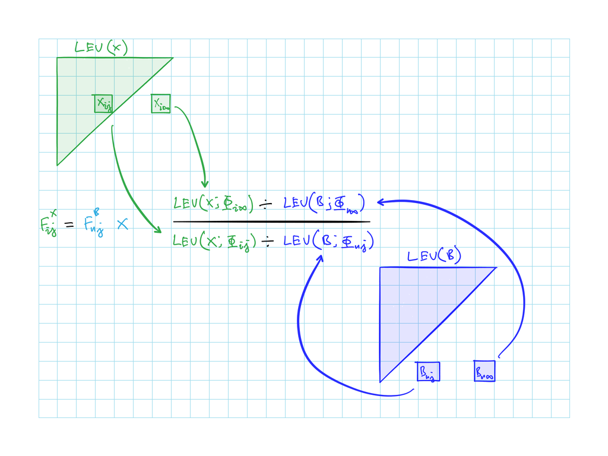

## LDFs for XS Layers

$\begin{align} F_{ij} = F_{nj}^B \times \frac{ \left[{\color{blue}{LEV(Y;\Phi_{i\infty}) - }} LEV(X;\Phi_{i\infty})\right]\div LEV(B;\Phi_{n\infty})}{ \left[ {\color{blue}{LEV(Y;\Phi_{ij}) - }} LEV(X;\Phi_{ij}) \right] \div LEV(B;\Phi_{nj})} \end{align}$

## Other Practical Uses

If we don’t have the severity distribution by age, we can work with the severity at ultimate and estimate $R_j(X,B)$, for lower layers $X < B$

$\begin{align} F_{ij}^X = F_{nj}^B \times \frac{LEV(X;\Phi_{i\infty})\div LEV(B;\Phi_{ {\color{red}i} \infty})}{R_j{(X,B)}} \end{align}$

**Estimate $R_j(X,B)$**

$U_i \leq R_j(X,B) \leq U_i \cdot F_{ij}^{\infty} \leq 1$

- $U_i = R_{i\infty}(X,B) = \dfrac{LEV(X;\Phi_{i\infty})}{LEV(B;\Phi_{i \infty})}$
- We expect $U_i$ to $\downarrow$ for more recent AYs due to loss trend; Larger % of losses pierce the lower layer
- $U_i$ increases as we move cross maturity (not sure how this works as these are ult…)
- $U_i$ is the ratio at ultimate of limited means; same as $R_{i \infty}$

Example from text:

- Select a decay from 1.000 and approaches $U_i$ as maturity increase
- Overlay with empirical $R_j(X,B)$ along the diagonal

Estimate doesn’t work when:

- There is expected negative development
- XS layer develops more quickly than a working layer

## Issues with Assumptions

Three assumptions that are **likely reasonable**

1. Must select a basic limit $B$
2. Needs an ultimate claim size model
   - Or use ILFs
   - Just have to accurate around the basic limit and policy limit since that’s where we calculate expectations
3. Need to create a triangle of losses at basic limit and one cost level
   - We do this in the step converting the base triangle

Two assumptions that are **more tenuous**

1. Requires robust claim size model at each age
   - Ultimately we need the ratio of limited losses at different layers right, not the absolute value
2. Trend
   - Trend should be applied to the incremental losses
   - Not clear how to apply trend to reported losses (by day of reserve or payment?)

## Past Exam Questions

n/a